# Análisis Temporal y Demográfico de las Principales Causas de Muerte en Estados Unidos

**Valerie M y Luis C**

2026-04-11

# **Análisis Exploratorio de Mortalidad en EE.UU. (1999-2017)**

# 1. Introducción

## **1.1. Contexto del Problema**

Las enfermedades crónicas no transmisibles provocan la mayoría de los fallecimientos en Estados Unidos. El cáncer, enfermedades cardíacas, diabetes, enfermedades cerebrovasculares, Alzheimer, enfermedades respiratorias crónicas y enfermedades renales han sido motivos comunes de muerte. Además, existen causas externas (CDC/NCHS 2017). Se consideran factores externos de fallecimiento las lesiones no intencionales, los accidentes y el suicidio, conectadas con la manera en que vivimos y las circunstancias que nos envuelven. Determinado por varios factores, incluyendo el lugar y la forma en que vivimos, las predisposiciones genéticas y si contamos con el acceso a una atención médica de alta calidad (CDC/NCHS 2017). Sin embargo, los cambios en la salud son difíciles de entender sin primero analizar su evolución.

Como demostró James, Cossman, and Wolf (2018), que examinó 48 años de información sobre mortalidad entre 1968 y 2015 y fue publicado en *Demographic Research*, la mortalidad no es uniforme en todo el territorio, las disparidades geográficas son variables que se mantienen con el tiempo. En el sur rural, en los condados de Mississippi, Alabama, Kentucky y Tennessee, se localizan las zonas con más muertes. Es alarmante la diferencia de mortalidad entre esta región y el resto del país. En la década de 1960, el número de muertes era alrededor de 50 por cada 100,000 habitantes; sin embargo, para el año 2015 ese número se incrementó a 220, los autores la llaman, *"The difference between the Heart of America and Dixiela"*. Tendencia vinculada a la presencia de disparidades en las tasas de mortalidad, más pronunciadas en el sureste estadounidense.

Este estudio cubre el periodo 1999-2017 (Shah et al. 2019). En el pasado estudio, se demuestra la continuidad de las enfermedades crónicas como causa de muerte, así como la evolución de las diferentes causas, como ocurre con los suicidios y los accidentes, que cobran más importancia en las últimas décadas (Daugherty et al. 2019). Años esenciales para entender el perfil de salud del país antes de la llegada de la pandemia de COVID-19. El estudio presta atención a las diferencias geográficas que la revisión de literatura ha señalado. En particular, este análisis abordará las siguientes causas de muerte: enfermedades del corazón, cáncer, accidentes cerebrovasculares (stroke), enfermedades respiratorias crónicas (CLRD), accidentes no intencionales, Alzheimer, diabetes, enfermedades renales, influenza/neumonía y suicidio.

## **1.2. Contexto del Dataset**

El dataset utilizado en este informe es *"NCHS - Leading Causes of Death: United States"*. Los **Centers for Disease Control and Prevention (CDC)** son la agencia nacional de salud pública de Estados Unidos y constituyen la principal fuente de información epidemiológica del país. A través del **National Center for Health Statistics (NCHS)** y el **National System of Vital Statistics (NVSS)**, los CDC recolectan todos los certificados de defunción emitidos en los 50 estados y el **District of Columbia**, lo que garantiza que los datos provienen del registro universal de todos los fallecimientos.

## **1.3. Pregunta Central de Investigación**

Este análisis se articula en torno a la siguiente pregunta:

**¿Cómo han cambiado las principales causas de muerte en Estados Unidos a lo largo del tiempo (1999-2017) y qué diferencias persistentes se observan entre los distintos estados?**

La anterior pregunta abarca tres dimensiones fundamentales sobre la investigación:

1. **Dimensión temporal:** Tenemos en cuenta la evolución de las enfermedades crónicas y las causas externas en las últimas décadas. Por esta razón, analizamos cómo han variado las causas de muerte y la medida en la que estas causas son diferentes.
2. **Dimensión geográfica:** Es necesario identificar si la mortalidad tiene un impacto distinto o si varía de acuerdo al estado. Analizando las desigualdades territoriales que la literatura nos ha documentado.
3. **Dimensión de ranking:** Para tener una visión clara sobre las causas de muerte y la existencia de diferencias en el patrón a lo largo de los diferentes estados del país, es esencial identificar cómo han cambiado con el tiempo.

## 1.4. Objetivos del Estudio

### 1.4.1 Objetivo General

Analizar la evolución de la mortalidad en Estados Unidos de 1999 hasta 2017, identificando sus principales causas y distribución geográfica, mediante análisis exploratorio de datos, el desarrollo de un dashboard interactivo y la implementación de un modelo de predicción.

### 1.4.2 Objetivos Específicos

1. **Descripción del panorama general de la mortalidad en Estados Unidos durante el periodo de 1999-2017:** Identificar el volumen anual de muertes y causas más frecuentes a nivel nacional en este período, para construir así una perspectiva global.
2. **Determinar el avance temporal de las causas principales:** Identificar los patrones existentes en las causas. En consecuencia, nuestro punto de partida es el incremento de muertes por accidentes y la evolución de las enfermedades crónicas en las últimas dos décadas.
3. **Disparidades geográficas:** Comparación entre las tasas ajustadas de mortalidad y los distintos estados, para así poder determinar las áreas con mayores cargas de mortalidad.
4. **Visualizar el dinamismo del ranking de las diferentes causas de muerte:** Las posiciones de cada causa han cambiado a lo largo del período; es necesario establecer cuáles adquieren o pierden jerarquía en el contexto nacional.
5. **Formular hipótesis e insights basados en los patrones encontrados:** A partir de los patrones encontrados y basándose en los resultados del análisis, dirigidas especialmente a las regiones con mortalidad persistentemente alta.

# 2. **Marco Teórico**

Sustentar el análisis apoyado en la evidencia de la revisión de literatura especializada, determinando el estado del conocimiento sobre las tendencias y las disparidades en mortalidad en los Estados Unidos entre 1999 y 2017.

## 2.1. Prevalencia de las enfermedades crónicas en EE. UU.

Como la mayoría de las naciones desarrolladas, hace décadas Estados Unidos experimentó un cambio epidemiológico. Las enfermedades infecciosas dejaron de ser las principales causas de muerte, posibilitando el predominio de enfermedades crónicas y degenerativas. Desde la mitad del siglo XX las enfermedades cardiovasculares, el cáncer y enfermedades cerebrovasculares han mantenido una posición en los primeros puestos de las cifras de mortalidad en el país (Shah et al. 2019).

La evolución de estas enfermedades no ha sido estática. Investigaciones recientes documentan que, tras décadas de reducción sostenida, la mortalidad por enfermedades cardiovasculares comenzó a estabilizarse alrededor de 2010 (Shah et al. 2019). De igual forma, otras causas como el Alzheimer, diabetes y las enfermedades renales han incrementado su contribución relativa al total de defunciones en el país, reflejando el envejecimiento poblacional y el aumento de condiciones metabólicas como la obesidad (Shah et al. 2019).

A estas causas se añaden otros nuevos factores. Como las muertes por causas externas, suicidios y accidentes no intencionales. Los accidentes, en particular, han mostrado un crecimiento en este último siglo, impulsados principalmente por intoxicaciones accidentales relacionadas con el consumo de drogas, aunque también influyen accidentes de tráfico, caídas y otros eventos prevenibles (Daugherty et al. 2019).

## **2.2. Las disparidades geográficas como patrón persistente**

Uno de los descubrimientos más sólidos en la literatura acerca de la mortalidad en Estados Unidos es que hay un "gradiente geográfico" que perjudica de manera sistemática al sureste del país. Según la investigación de James, Cossman, and Wolf (2018), que examinó 48 años de datos (1968-2015), los condados con una alta mortalidad sostenida se encuentran en la división Este Sur Central (Alabama, Kentucky, Mississippi y Tennessee). La brecha en mortalidad entre esta región y el resto del país aumentó significativamente. En cincuenta años, pasó de 50 a 220 muertes por cada 100,000 habitantes. Según los autores, este aumento se debe a varios factores. Entre ellos, se encuentran un nivel socioeconómico más bajo, el acceso limitado a servicios de salud y una mayor prevalencia de conductas de riesgo.

## **2.3. La importancia del análisis temporal y por ranking**

Se ha demostrado por medio de la literatura la existencia de cambios significativos en las causas de muerte a lo largo del periodo. Existe un aumento en enfermedades como el Alzheimer debido al envejecimiento de la población. Igualmente, los accidentes también han aumentado debido a la crisis de los opioides. Las variaciones en el ranking representan cambios tanto en los perfiles de riesgo de la población y en la eficacia de las intervenciones de salud pública; su seguimiento es fundamental.

# 3. Metodología

El presente estudio corresponde a un **análisis exploratorio de datos (EDA) de corte longitudinal**, basado en registros administrativos de mortalidad en Estados Unidos durante el periodo 1999-2017. El enfoque metodológico combina estadística descriptiva, análisis de series de tiempo, clustering y modelado predictivo.

## 3.1. Fuente de datos y preprocesamiento

El conjunto contiene registros anuales de mortalidad por causa y estado, incluyendo la tasa ajustada por edad (*age-adjusted death rate*), que estandariza las tasas eliminando el efecto de diferencias en la estructura etaria entre poblaciones, permitiendo comparaciones entre estados y años. El preprocesamiento incluyó estandarización de nombres de variables, corrección de formatos numéricos inconsistentes, conversión de tipos de datos y filtrado del periodo 1999-2017.

## 3.2. Estadística descriptiva

Como punto de partida se construyeron diagramas de barras comparativos para analizar la distribución porcentual de las causas de muerte de 1999-2017 y gráficos de líneas para identificar la evolución temporal de las tasas ajustadas por causa a nivel nacional. Estas visualizaciones permiten detectar tendencias, cambios en el ranking de causas y variaciones en la carga relativa de cada enfermedad a lo largo del período.

## 3.3. Análisis de series de tiempo

Se aplicaron las siguientes técnicas para evaluar el comportamiento temporal de las series de mortalidad:

- **Estacionariedad:** Se evaluó mediante la **prueba de Dickey-Fuller Aumentada (ADF)**, cuya hipótesis nula establece que la serie tiene raíz unitaria (no estacionaria). Un valor p < 0.05 indica estacionariedad, requisito para la aplicación de modelos ARIMA.
- **ACF y PACF:** Se analizaron las funciones de autocorrelación (ACF) y autocorrelación parcial (PACF) para identificar patrones de dependencia temporal y orientar la selección de parámetros del modelo.

## 3.6. Modelo predictivo - ARIMA

Para proyectar tendencias futuras se implementó un modelo **ARIMA(p,d,q)**, definido por tres parámetros: orden autoregresivo (p), el grado de diferenciación (d) y el orden de media móvil (q). La selección de parámetros óptimos se realizó mediante el **criterio de información de Akaike (AIC)**. La validación se realizó mediante análisis de residuos y la **prueba de Ljung-Box**, cuya hipótesis nula establece independencia de los residuos; un p-value > 0.05 confirma que el modelo no dejó estructura sin capturar. Las proyecciones cubren 2018-2022 para West Virginia.

## 3.7. Herramientas Computacionales

```
import pandas as pd
import numpy as np
import matplotlib.pyplot as plt
import matplotlib.ticker as mticker
import matplotlib.patches as mpatches
import seaborn as sns
import warnings
from scipy import stats
import plotly.express as px
from sklearn.preprocessing import StandardScaler
from sklearn.cluster import KMeans
from sklearn.decomposition import PCA
from sklearn.metrics import silhouette_score
import pmdarima as pm
from statsmodels.tsa.stattools import adfuller
from statsmodels.graphics.tsaplots import plot_acf, plot_pacf
from statsmodels.stats.diagnostic import acorr_ljungbox
```

El procesamiento y análisis de los datos se realizó utilizando el lenguaje de programación **Python** y el entorno de desarrollo Jupyter Notebook. Las principales librerías empleadas fueron:

- `pandas` y `numpy`: para manipulación y transformación de datos.
- `matplotlib` y `seaborn`: para visualizaciones estáticas.
- `plotly.express`: para mapas coropléticos interactivos.
- `scipy.stats`: para regresión lineal y pruebas estadísticas.
- `sklearn`: para estandarización, K-Means y PCA.
- `pmdarima`: para selección automática del modelo ARIMA.
- `statsmodels`: para prueba ADF, ACF/PACF y diagnóstico de residuos.

## 3.8. Carga y limpieza de datos

```
FILE = "NCHS_-_Leading_Causes_of_Death__United_States.csv"
df_raw = pd.read_csv(FILE)

df_raw.columns = (
    df_raw.columns.str.strip().str.lower()
    .str.replace(' ', '_').str.replace('-', '_')
)

rename_map = {
    'year'                   : 'anio',
    'cause_name'             : 'causa',
    'state'                  : 'estado',
    'deaths'                 : 'muertes',
    'age_adjusted_death_rate': 'tasa_ajustada'
}
df = df_raw.rename(columns=rename_map).copy()

datos = df[
    (df['estado'] == 'United States') &
    (df['anio'] >= 1999) & (df['anio'] <= 2017)
][['anio', 'causa', 'muertes', 'tasa_ajustada']].copy()

datos_estados = df[
    (df['estado'] != 'United States') &
    (df['anio'] >= 1999) & (df['anio'] <= 2017)
].copy()
```

## **3.9. Variables del Dataset**

| Variable | Descripción | Tipo |
| --- | --- | --- |
| `anio` | Año del registro (1999-2017) | Numérico |
| `causa` | Nombre de la causa de muerte | Categórico |
| `estado` | Estado o "United States" (nacional) | Categórico |
| `muertes` | Número absoluto de muertes | Numérico |
| `tasa_ajustada` | Tasa ajustada por edad por 100,000 hab. | Numérico |

## **3.3. Comparación porcentual de muertes por causa: 1999 vs 2017**

Al comparar el peso porcentual de cada causa de muerte sobre el total anual entre 1999 y 2017, se observan cambios significativos en la composición de la mortalidad. Las enfermedades del corazón han reducido su participación relativa, reflejando décadas de avances en cardiología y prevención. Las lesiones no intencionales aumentaron notablemente su peso relativo, fenómeno directamente vinculado a la crisis de sobredosis de opioides.

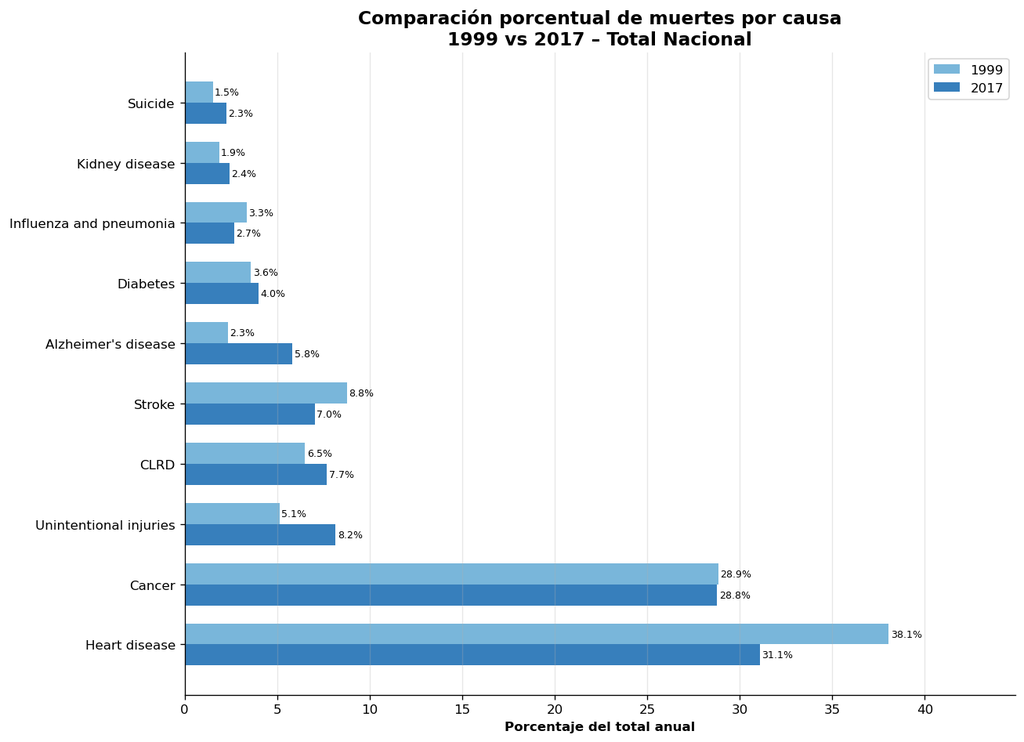

Figura 1. Comparación porcentual de muertes por causa: 1999 vs 2017 - Total Nacional

# **4. Evolución de la tasa ajustada de mortalidad anual**

La tasa ajustada de mortalidad para todas las causas en los Estados Unidos descendió de manera sostenida desde 1999 hasta alrededor de 2012, reflejando los avances en atención médica, reducción del tabaquismo y mejoras en el control de factores de riesgo cardiovascular. A partir de 2013-2014 se observa una desaceleración de esta caída, con un leve repunte en 2017, coherente con el impacto de la epidemia de opioides y el aumento del suicidio en ciertos segmentos poblacionales.

[output not shown]

[figure not shown]

Figura 2. Evolución de la tasa ajustada de mortalidad nacional (1999-2017) con tendencia lineal

**Interpretación:** La regresión lineal confirma una pendiente negativa estadísticamente significativa para el período completo, con una reducción aproximada del 13% en la tasa ajustada entre 1999 y 2017. La inflexión a partir de 2013 señala el inicio del impacto visible de la crisis de opioides sobre la mortalidad nacional.

# **5. Análisis de Ranking: Cambios en la Posición de las Causas de Muerte**

## **5.1. Ranking de causas por año**

La evolución de las tasas ajustadas por causa revela trayectorias muy distintas. Las enfermedades del corazón y el cáncer lideran en términos absolutos, pero mientras la mortalidad cardiovascular cae sostenidamente, las lesiones no intencionales registran el aumento más pronunciado, convirtiéndose en la crisis de salud pública más relevante de la primera mitad del siglo XXI en EE.UU.

[figure not shown]

Figura 3. Evolución de las tasas de mortalidad ajustadas por edad - Top 10 causas (1999-2017)

## **5.2. Cambios en el ranking: 1999 vs 2017**

Más allá de las tasas absolutas, el cambio en el posicionamiento relativo de cada causa ofrece una perspectiva poderosa sobre qué amenazas han ganado importancia y cuáles han retrocedido. Las lesiones no intencionales y la enfermedad de Alzheimer son las que más posiciones han ganado en el ranking, mientras que las enfermedades cardiovasculares y la neumonía/influenza cedieron posiciones gracias a los avances en prevención y tratamiento.

# **6. Análisis Específico: La Crisis de las "Muertes por Desesperación"**

El economista Angus Deaton, Premio Nobel de Economía 2015, popularizó el concepto de *"deaths of despair"* (muertes por desesperación) para describir el incremento de la mortalidad causada por sobredosis de drogas, suicidio y alcoholismo en la clase trabajadora blanca estadounidense. Este fenómeno rompe con la tendencia histórica de mejora continua en la esperanza de vida.

## **6.1. Evolución conjunta de suicidio y accidentes**

Los datos muestran que tanto el suicidio como las lesiones no intencionales presentan una tendencia creciente a lo largo del período analizado. El punto de inflexión más dramático ocurre alrededor de 2013-2014, coincidiendo con la tercera ola de la crisis de opioides, marcada por la introducción masiva del fentanilo en el mercado ilícito. La línea suavizada (media móvil de 3 años) permite distinguir el patrón estructural de largo plazo del ruido de corto plazo.

[figure not shown]

Figura 4. Evolución de las "Muertes por Desesperación" - Suicidio y Lesiones No Intencionales (1999-2017). Línea continua = datos reales; línea discontinua = media móvil 3 años

# 7. Distribución por causas principales (top 10)

[figure not shown]

Figura 5. Top 10 Causas de Muerte en EE.UU. - Total acumulado de muertes (1999-2017)

# 8. Series de tiempo por causa

## 8.1. Causa vs Año

[figure not shown]

Figura 6. Paneles de tasa ajustada por causa - Promedio nacional (1999-2017)

Los diagramas de caja y bigotes agrupan los datos en bloques de dos años, permitiendo observar cómo evoluciona la dispersión de cada causa a lo largo del período. Las enfermedades cardíacas muestran una mediana decreciente con dispersión reducida en los bloques más recientes, mientras que las lesiones no intencionales exhiben un aumento progresivo de la mediana, coherente con la heterogeneidad del impacto de la crisis de opioides entre estados.

[figure not shown]

Figura 7. Distribución semestral de tasas de mortalidad - Diagramas de caja por bloques de 2 años (1999-2017)

## **8.2. Heatmap de muertes absolutas por causas y años**

El mapa de calor permite una lectura simultánea de todas las causas y todos los años. La intensidad del color codifica el número absoluto de muertes: celdas más oscuras indican mayor mortalidad. Las enfermedades del corazón y el cáncer son las filas más oscuras, mientras que la enfermedad de Alzheimer muestra un oscurecimiento progresivo hacia los años más recientes, confirmando su crecimiento sostenido.

[figure not shown]

Figura 8. Heatmap de intensidad de muertes absolutas por causa y año (1999-2017). Celdas más oscuras = mayor número de muertes

## 8.3. Análisis Geográfico: Disparidades por Estado

### **8.3.3. Estados con mayor y menor mortalidad**

La comparación entre el estado con mayor tasa ajustada (West Virginia) y los estados con las tasas más bajas (Hawaii, Minnesota) ilustra la magnitud de las disparidades geográficas en EE.UU. Esta brecha tiene raíces profundas en factores socioeconómicos, acceso a servicios de salud y prevalencia de conductas de riesgo, como ha documentado ampliamente la literatura.

# 9. Caso de estudio: West Virginia

## 9.1. Evolución de las causas de muerte en West Virginia (1999-2017)

[figure not shown]

Figura 9. West Virginia - Evolución de todas las causas (1999-2017). Rojo = Unintentional injuries; gris = otras causas

### 9.1.1. ¿Qué explica el crecimiento de las lesiones no intencionales en West Virginia?

West Virginia es el estado más afectado por la epidemia de opioides en los Estados Unidos. Factores estructurales como la desindustrialización del sector minero, el desempleo crónico, la pobreza y el acceso limitado a servicios de salud mental crearon el caldo de cultivo para la crisis. La saturación del mercado con opioides de prescripción en la década de 2000, seguida por la transición al fentanilo ilícito a partir de 2013-2014, produjo el aumento exponencial de muertes por sobredosis observado en los datos.

## 9.2. Comparación de muertes por causa: West Virginia 1999 vs. 2017

La comparación directa entre 1999 y 2017 en número absoluto de muertes confirma la magnitud del cambio. Las lesiones no intencionales y el Alzheimer muestran los mayores aumentos absolutos, mientras que las enfermedades cardiovasculares y el stroke presentan reducciones.

[figure not shown]

## 9.3. West Virginia vs. Promedio Nacional (1999-2017)

La brecha entre la tasa de West Virginia y el promedio nacional se amplía progresivamente. El área sombreada entre ambas líneas crece de forma acelerada tras 2010, cuantificando visualmente la magnitud de la crisis. En 2017, West Virginia registra una tasa ajustada significativamente superior a la del segundo estado más afectado.

[figure not shown]

Figura 11. West Virginia vs. Promedio Nacional - Tasa ajustada (1999-2017). Área sombreada = brecha acumulada

# 10. Clustering de estados por perfil de mortalidad

## 10.1. Preparación de datos

Para identificar grupos de estados con perfiles de mortalidad similares, se construyó una matriz de tasas ajustadas promedio (1999-2017) donde cada fila es un estado y cada columna es una causa de muerte. Se eliminaron los registros con valores faltantes y se estandarizaron las variables para garantizar que causas con tasas más altas no dominen el agrupamiento.

```
cluster_data = (
    datos_estados[datos_estados['causa'] != 'All causes']
    .groupby(['estado', 'causa'])['tasa_ajustada'].mean()
    .reset_index()
)
pivot_cluster = cluster_data.pivot(
    index='estado', columns='causa', values='tasa_ajustada').dropna()

scaler = StandardScaler()
X_scaled = scaler.fit_transform(pivot_cluster)
```

## 10.2. Estandarización y número óptimo de clústeres (método del codo)

[figure not shown]

Figura 12. Método del Codo y Silhouette Score - Selección del número óptimo de clústeres

## 10.3. Modelo K-Means y composición de clústeres

Con k=4, el modelo K-Means asigna cada estado a uno de cuatro grupos. El clúster con las tasas más altas agrupa estados del sur y Apalaches (West Virginia, Mississippi, Alabama); el de tasas más bajas concentra estados del noreste y costa oeste.

## 10.4. Visualización PCA - posicionamiento de los estados

El análisis de componentes principales (PCA) reduce la dimensionalidad del espacio multivariante a dos dimensiones, preservando la mayor parte de la varianza. Cada punto representa un estado, coloreado según su clúster. Los estados del mismo grupo aparecen cercanos en el plano PCA, confirmando la coherencia del agrupamiento.

[figure not shown]

Figura 13. Clustering K-Means (k=4) - Visualización PCA. Estados agrupados por perfil de mortalidad 1999-2017

# 11. Modelo Predictivo ARIMA

## 11.1. Construcción de las series de tiempo

Se construyeron series de tiempo de la tasa ajustada por causa a nivel nacional (1999-2017). La visualización preliminar de cada serie permite identificar tendencias, estacionalidades y posibles quiebres estructurales antes de aplicar el modelo formal.

[figure not shown]

Figura 14. Series de tiempo por causa - Tasa ajustada nacional (1999-2017)

## 11.3. ACF y PACF - identificación visual del orden

Las funciones de autocorrelación (ACF) y autocorrelación parcial (PACF) de la serie diferenciada de West Virginia permiten identificar los órdenes AR (p) y MA (q) del modelo. Los rezagos cuyas barras superan las bandas de confianza azules son estadísticamente significativos e informan la especificación del modelo ARIMA.

[figure not shown]

Figura 15. ACF y PACF - West Virginia (serie diferenciada d=1). Barras fuera de la banda azul = rezagos significativos

## 11.4. Selección automática del modelo

Se utilizó `pmdarima.auto_arima` con criterio AIC para seleccionar automáticamente el orden óptimo (p, d, q) del modelo ARIMA. El modelo seleccionado minimiza el AIC entre todas las combinaciones evaluadas con p en [0,3] y q en [0,3].

## 11.5. Diagnóstico de residuos

Un modelo ARIMA bien ajustado produce residuos que se comportan como ruido blanco: sin autocorrelación, distribución aproximadamente normal y media cero. La prueba de Ljung-Box con p-valor mayor a 0.05 confirma que el modelo no dejó estructura sin capturar.

[figure not shown]

Figura 16. Diagnóstico de residuos del modelo ARIMA - West Virginia. Serie de residuos, histograma y ACF de residuos

## 11.6. Proyecciones ARIMA - West Virginia (2018-2022)